# Intro to data visualization with ggplot2

### Divide by day but split into two columns

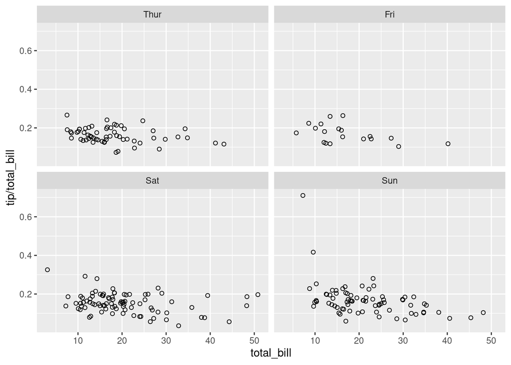

```r
# Divide by day, going horizontally and wrapping with 2 columns
sp + facet_wrap( ~ day, ncol=2)
```

### Color facets strips

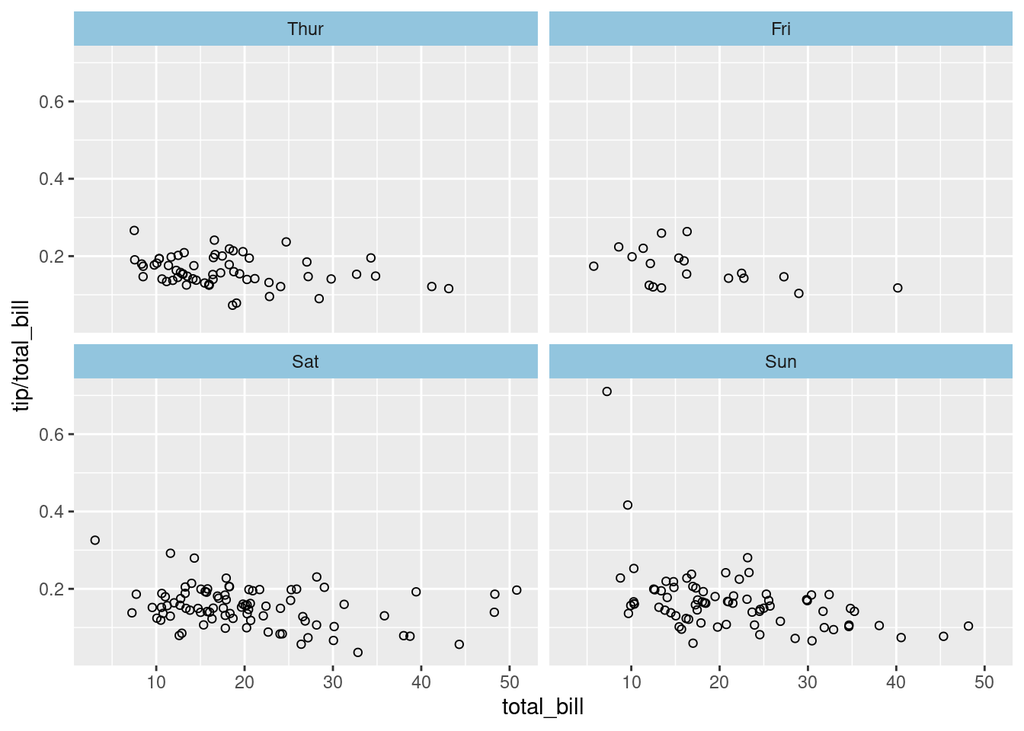

```r
# Divide by day, going horizontally and wrapping with 2 columns
sp + facet_wrap( ~ day, ncol=2, ) +
  theme(strip.background = element_rect(fill = "#92c5de"))
```

## Saving plots

Plots generated using ggplot2 can be saved to file using the `ggsave` function. The function will save, by default, the last plot to file.

```r
ggsave(plotname, filename, output_parameters)

# For example, this will save the plot "plt" into a
# file name "histogram_plot.pdf" as a PDF with 300 dpi at 4in x 4in
plt <- ggplot(data, aes(ratings)) + geom_hist()
ggsave(plt, "histogram_plot.pdf", width = 4, height = 4, dpi = 300)
```

**File formats**: pdf, png, jpeg, tiff, eps, ps, bmp, svg

Alternatively, you can use the baseR method to save the plots (see below).

```r
# PDFs
pdf("plots.pdf") #svg
plot(...)
plot(...)
dev.off()

# PNG/TIFF
png("plot.png") # or tiff("plot.tiff")
plot(...)
dev.off()

# resizing plot
png("plot.png", width=480, height=240, res=120)
plot(...)
dev.off()
```

**Warning**

You must use the `dev.off()` command to tell R that you are finished plotting; otherwise your graph will not show up.

If you generate plots with `ggplot2` in a script or function, you must use the print() command to render the plots.